# Credit Risk Analysis

Jagger Robles-Holmes

2025-04-05

```r
# Load data
credit_data <- read.csv("C:/Users/jagge/Downloads/credit_risk_dataset.csv/credit_risk_dataset.csv")
```

```r
# Check structure
glimpse(credit_data)
```

```
## Rows: 32,581
## Columns: 12
## $ person_age                 <int> 22, 21, 25, 23, 24, 21, 26, 24, 24, 21, 22,…
## $ person_income              <int> 59000, 9600, 9600, 65500, 54400, 9900, 7710…
## $ person_home_ownership      <chr> "RENT", "OWN", "MORTGAGE", "RENT", "RENT", …
## $ person_emp_length          <dbl> 123, 5, 1, 4, 8, 2, 8, 5, 8, 6, 6, 2, 2, 4,…
## $ loan_intent                <chr> "PERSONAL", "EDUCATION", "MEDICAL", "MEDICA…
## $ loan_grade                 <chr> "D", "B", "C", "C", "C", "A", "B", "B", "A"…
## $ loan_amnt                  <int> 35000, 1000, 5500, 35000, 35000, 2500, 3500…
## $ loan_int_rate              <dbl> 16.02, 11.14, 12.87, 15.23, 14.27, 7.14, 12…
## $ loan_status                <int> 1, 0, 1, 1, 1, 1, 1, 1, 1, 1, 1, 1, 1, 1, 0…
## $ loan_percent_income        <dbl> 0.59, 0.10, 0.57, 0.53, 0.55, 0.25, 0.45, 0…
## $ cb_person_default_on_file  <chr> "Y", "N", "N", "N", "Y", "N", "N", "N", "N"…
## $ cb_person_cred_hist_length <int> 3, 2, 3, 2, 4, 2, 3, 4, 2, 3, 4, 2, 2, 4, 4…
```

```r
# Summary statistics
summary(credit_data)
```

```
##    person_age     person_income     person_home_ownership person_emp_length
##  Min.   : 20.00   Min.   :   4000   Length:32581          Min.   :  0.00
##  1st Qu.: 23.00   1st Qu.:  38500   Class :character      1st Qu.:  2.00
##  Median : 26.00   Median :  55000   Mode  :character      Median :  4.00
##  Mean   : 27.73   Mean   :  66075                         Mean   :  4.79
##  3rd Qu.: 30.00   3rd Qu.:  79200                         3rd Qu.:  7.00
##  Max.   :144.00   Max.   :6000000                         Max.   :123.00
##                                                           NA's   :895
##  loan_intent         loan_grade          loan_amnt     loan_int_rate
##  Length:32581       Length:32581       Min.   :  500   Min.   : 5.42
##  Class :character   Class :character   1st Qu.: 5000   1st Qu.: 7.90
##  Mode  :character   Mode  :character   Median : 8000   Median :10.99
##                                        Mean   : 9589   Mean   :11.01
##                                        3rd Qu.:12200   3rd Qu.:13.47
##                                        Max.   :35000   Max.   :23.22
##                                                        NA's   :3116
##   loan_status     loan_percent_income cb_person_default_on_file
##  Min.   :0.0000   Min.   :0.0000      Length:32581
##  1st Qu.:0.0000   1st Qu.:0.0900      Class :character
##  Median :0.0000   Median :0.1500      Mode  :character
##  Mean   :0.2182   Mean   :0.1702
##  3rd Qu.:0.0000   3rd Qu.:0.2300
##  Max.   :1.0000   Max.   :0.8300
##
##  cb_person_cred_hist_length
##  Min.   : 2.000
##  1st Qu.: 3.000
##  Median : 4.000
##  Mean   : 5.804
##  3rd Qu.: 8.000
##  Max.   :30.000
##
```

```r
# Check for missing values
colSums(is.na(credit_data))
```

```
##                 person_age              person_income
##                          0                          0
##      person_home_ownership          person_emp_length
##                          0                        895
##                loan_intent                 loan_grade
##                          0                          0
##                  loan_amnt              loan_int_rate
##                          0                       3116
##                loan_status        loan_percent_income
##                          0                          0
##  cb_person_default_on_file cb_person_cred_hist_length
##                          0                          0
```

```r
# Cap person_age at 80
credit_data <- credit_data %>%
  mutate(person_age = ifelse(person_age > 80, 80, person_age))
```

```r
# Impute loan_int_rate with median
credit_data$loan_int_rate[is.na(credit_data$loan_int_rate)] <- median(credit_data$loan_int_rate, na.rm = TRUE)

# Impute person_emp_length with 0 (assuming missing = unemployed)
credit_data$person_emp_length[is.na(credit_data$person_emp_length)] <- 0
```

```r
credit_data <- credit_data %>%
  mutate(
    person_home_ownership = as.factor(person_home_ownership),
    loan_intent = as.factor(loan_intent),
    loan_grade = as.factor(loan_grade),
    cb_person_default_on_file = as.factor(cb_person_default_on_file),
    loan_status = as.factor(loan_status)
  )
```

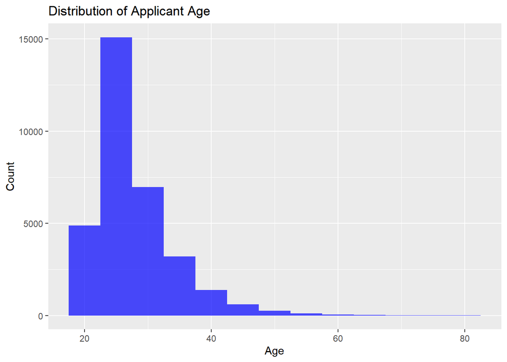

```r
# Age distribution
ggplot(credit_data, aes(x = person_age)) +
  geom_histogram(binwidth = 5, fill = "blue", alpha = 0.7) +
  labs(title = "Distribution of Applicant Age", x = "Age", y = "Count")
```

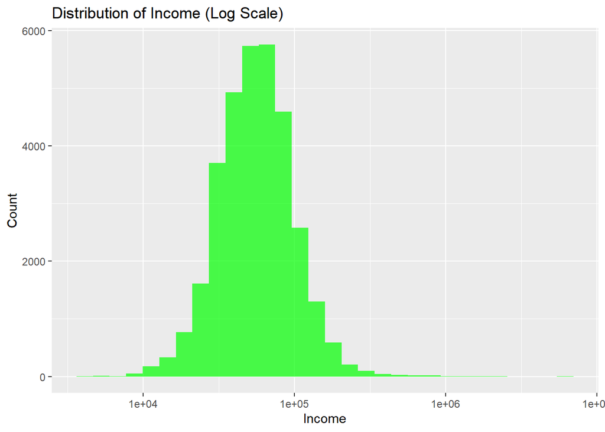

```r
# Income distribution (log scale for readability)
ggplot(credit_data, aes(x = person_income)) +
  geom_histogram(fill = "green", alpha = 0.7) +
  scale_x_log10() +  # Log-transform due to skewness
  labs(title = "Distribution of Income (Log Scale)", x = "Income", y = "Count")
```

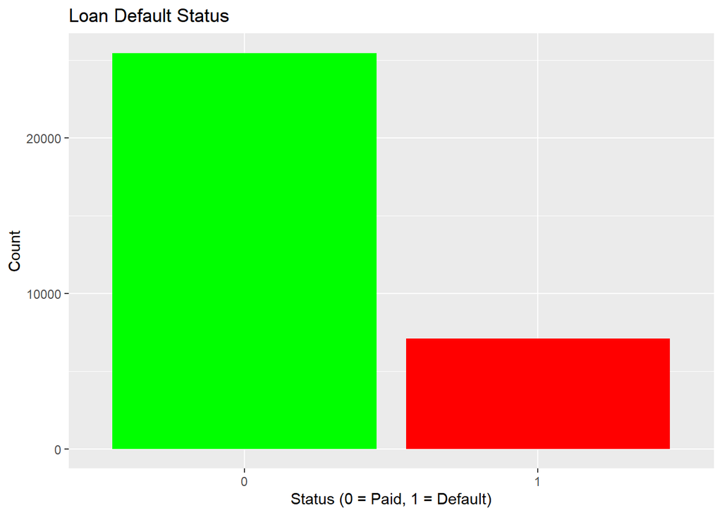

```r
# Loan status (target variable)
ggplot(credit_data, aes(x = loan_status)) +
  geom_bar(fill = c("green", "red")) +
  labs(title = "Loan Default Status", x = "Status (0 = Paid, 1 = Default)", y = "Count")
```

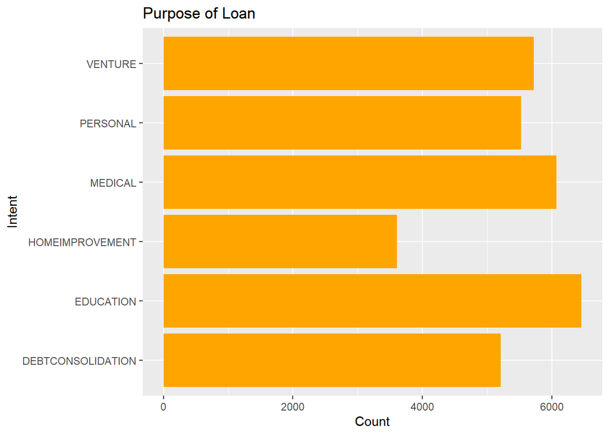

```r
# Loan intent
ggplot(credit_data, aes(x = loan_intent)) +
  geom_bar(fill = "orange") +
  coord_flip() +  # Horizontal bars for readability
  labs(title = "Purpose of Loan", x = "Intent", y = "Count")
```

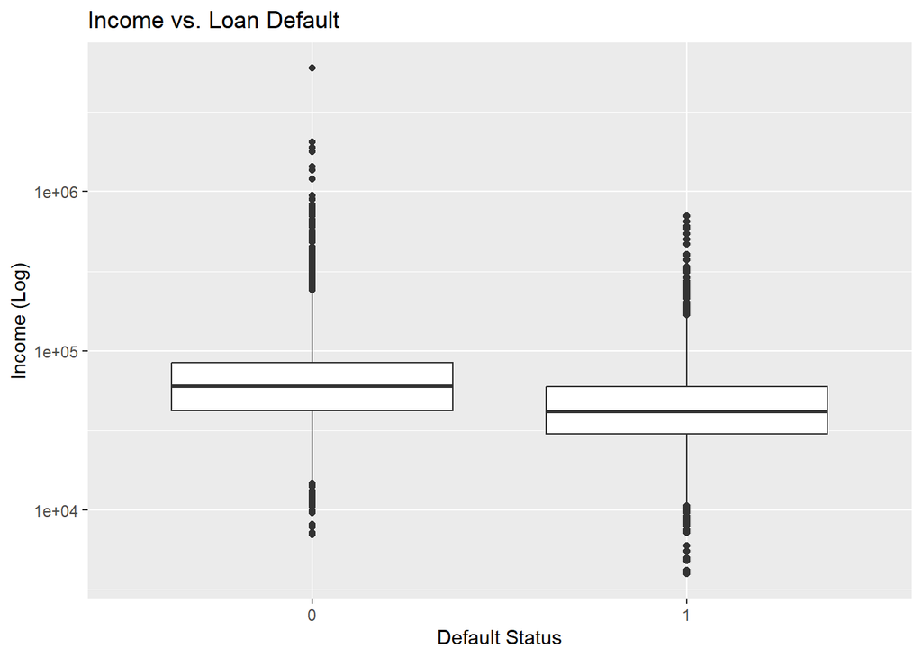

```r
# Income vs. Default
ggplot(credit_data, aes(x = loan_status, y = person_income)) +
  geom_boxplot() +
  scale_y_log10() +
  labs(title = "Income vs. Loan Default", x = "Default Status", y = "Income (Log)")
```

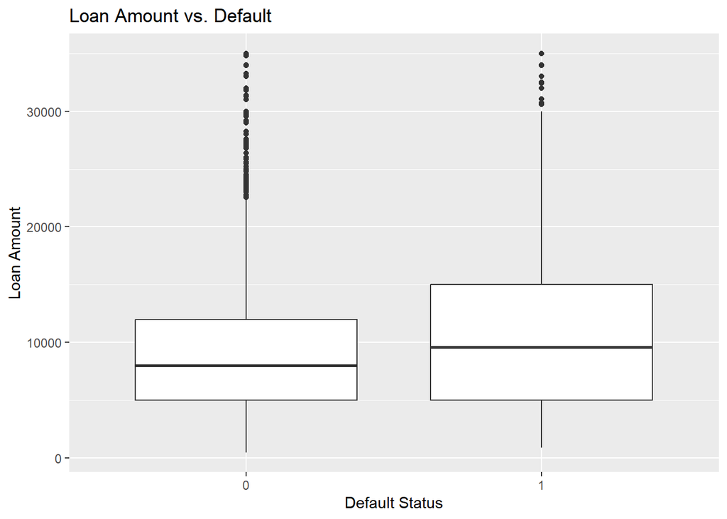

```r
# Loan amount vs. Default
ggplot(credit_data, aes(x = loan_status, y = loan_amnt)) +
  geom_boxplot() +
  labs(title = "Loan Amount vs. Default", x = "Default Status", y = "Loan Amount")
```

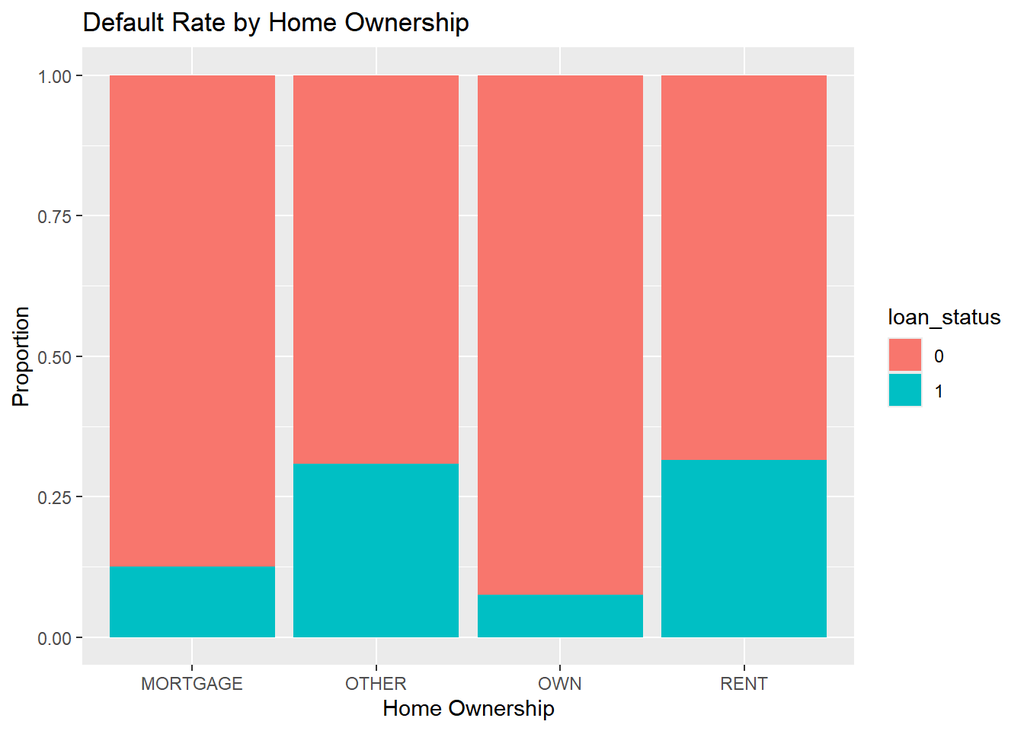

```r
# Default rate by home ownership
credit_data %>%
  group_by(person_home_ownership, loan_status) %>%
  summarise(count = n()) %>%
  mutate(percent = count / sum(count)) %>%
  ggplot(aes(x = person_home_ownership, y = percent, fill = loan_status)) +
  geom_col() +
  labs(title = "Default Rate by Home Ownership", x = "Home Ownership", y = "Proportion")
```

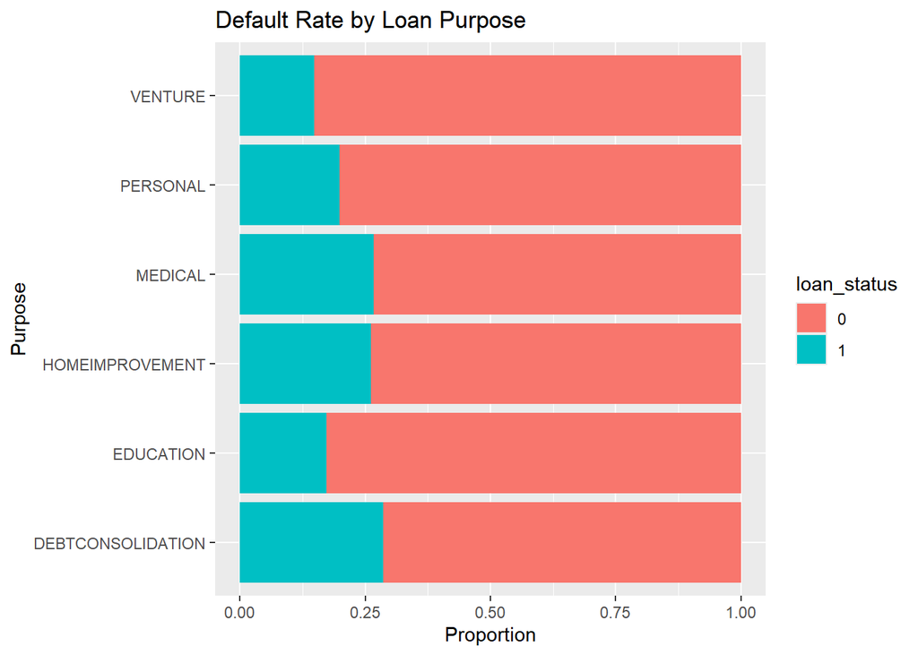

```r
# Default rate by loan intent
credit_data %>%
  group_by(loan_intent, loan_status) %>%
  summarise(count = n()) %>%
  mutate(percent = count / sum(count)) %>%
  ggplot(aes(x = loan_intent, y = percent, fill = loan_status)) +
  geom_col() +
  coord_flip() +
  labs(title = "Default Rate by Loan Purpose", x = "Purpose", y = "Proportion")
```

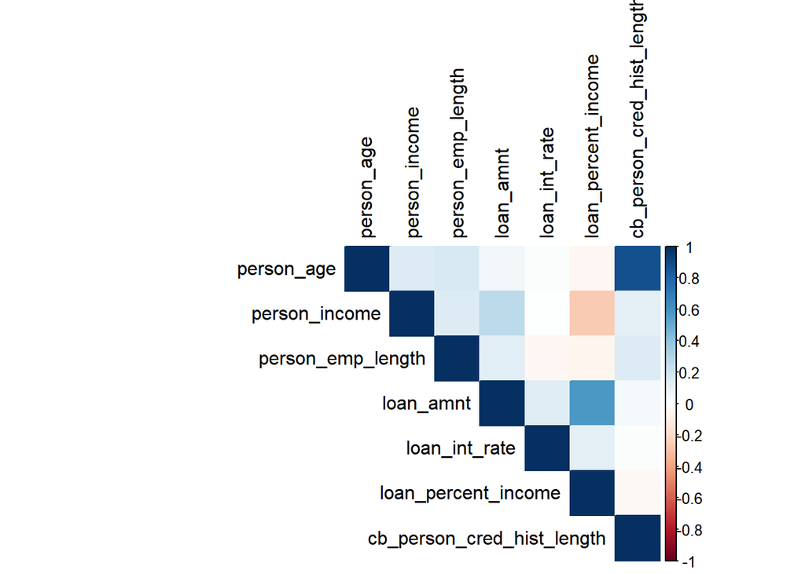

```r
# Select numeric variables only
numeric_data <- credit_data %>%
  select(person_age, person_income, person_emp_length, loan_amnt, loan_int_rate, loan_percent_income, cb_person_cred_hist_length)

# Compute correlation matrix
cor_matrix <- cor(numeric_data, use = "complete.obs")  # Handles any remaining NAs

# Plot correlations
corrplot(cor_matrix, method = "color", type = "upper", tl.col = "black")
```

```r
# Separate test and train data
set.seed(123)
train_index <- createDataPartition(credit_data$loan_status, p = 0.75, list = FALSE)
train_data <- credit_data[train_index, ]
test_data <- credit_data[-train_index, ]
```

```r
# log transformation reduces skewness
train_data$log_age <- log(train_data$person_age + 1)  # +1 to avoid log(0)
```

```r
# Easier for higher incomes to pay higher loans
train_data$income_loan_ratio <- train_data$person_income / train_data$loan_amnt
```

```r
# Highlights riskier categories
train_data$high_risk_purpose <- ifelse(train_data$loan_intent %in% c("DEBTCONSOLIDATION", "MEDICAL", "HOMEMPROVEMENT"), 1, 0)
```

```r
# Converts text to binary columns
dummies <- dummyVars(~ person_home_ownership + loan_intent + loan_grade, data = train_data)
train_encoded <- predict(dummies, newdata = train_data) %>% as.data.frame()
train_data <- cbind(train_data, train_encoded)
```

```r
# Logistic is good for binary classification
logit_model <- glm(
  loan_status ~ person_age + person_income + loan_amnt + loan_int_rate +
                cb_person_cred_hist_length + high_risk_purpose + income_loan_ratio,
  data = train_data,
  family = "binomial"
)
# Summary to check coefficients
summary(logit_model)
```

```
##
## Call:
## glm(formula = loan_status ~ person_age + person_income + loan_amnt +
##     loan_int_rate + cb_person_cred_hist_length + high_risk_purpose +
##     income_loan_ratio, family = "binomial", data = train_data)
##
## Deviance Residuals:
##     Min       1Q   Median       3Q      Max
## -2.2939  -0.6647  -0.3929  -0.1058   6.7225
##
## Coefficients:
##                              Estimate Std. Error z value Pr(>|z|)
## (Intercept)                -3.883e+00  1.488e-01 -26.087   <2e-16 ***
## person_age                 -1.397e-03  5.931e-03  -0.236    0.814
## person_income              -3.547e-05  1.042e-06 -34.026   <2e-16 ***
## loan_amnt                   1.082e-04  4.531e-06  23.889   <2e-16 ***
## loan_int_rate               2.856e-01  6.366e-03  44.858   <2e-16 ***
## cb_person_cred_hist_length  9.692e-05  9.073e-03   0.011    0.991
## high_risk_purpose           5.802e-01  3.614e-02  16.053   <2e-16 ***
## income_loan_ratio           6.698e-04  3.997e-03   0.168    0.867
## ---
## Signif. codes:  0 '***' 0.001 '**' 0.01 '*' 0.05 '.' 0.1 ' ' 1
##
## (Dispersion parameter for binomial family taken to be 1)
##
##     Null deviance: 25637  on 24435  degrees of freedom
## Residual deviance: 20031  on 24428  degrees of freedom
## AIC: 20047
##
## Number of Fisher Scoring iterations: 6
```

```r
logit_model_simple <- glm(
  loan_status ~ person_income + loan_amnt + loan_int_rate + high_risk_purpose,
  family = "binomial",
  data = train_data
)
# Check new summary
summary(logit_model_simple)
```

```
##
## Call:
## glm(formula = loan_status ~ person_income + loan_amnt + loan_int_rate +
##     high_risk_purpose, family = "binomial", data = train_data)
##
## Deviance Residuals:
##     Min       1Q   Median       3Q      Max
## -2.2952  -0.6646  -0.3926  -0.1059   6.7200
##
## Coefficients:
##                     Estimate Std. Error z value Pr(>|z|)
## (Intercept)       -3.914e+00  8.607e-02  -45.48   <2e-16 ***
## person_income     -3.540e-05  8.726e-07  -40.57   <2e-16 ***
## loan_amnt          1.077e-04  3.287e-06   32.77   <2e-16 ***
## loan_int_rate      2.855e-01  6.364e-03   44.87   <2e-16 ***
## high_risk_purpose  5.799e-01  3.613e-02   16.05   <2e-16 ***
## ---
## Signif. codes:  0 '***' 0.001 '**' 0.01 '*' 0.05 '.' 0.1 ' ' 1
##
## (Dispersion parameter for binomial family taken to be 1)
##
##     Null deviance: 25637  on 24435  degrees of freedom
## Residual deviance: 20031  on 24431  degrees of freedom
## AIC: 20041
##
## Number of Fisher Scoring iterations: 6
```

```r
# Create the same high_risk_purpose feature in test_data
test_data$high_risk_purpose <- ifelse(
  test_data$loan_intent %in% c("DEBTCONSOLIDATION", "MEDICAL", "HOMEMPROVEMENT"),
  1,  # High-risk
  0   # Low-risk
)

# Predict probabilities on test data
test_data$pred_prob <- predict(logit_model_simple, newdata = test_data, type = "response")
head(test_data$pred_prob)  # Show first few predicted probabilities
```

```
## [1] 0.2758223 0.5282577 0.9506090 0.8384521 0.4435173 0.1837048
```

```r
# Convert probabilities to binary predictions (threshold = 0.5)
test_data$pred_status <- ifelse(test_data$pred_prob > 0.5, 1, 0)

# Generate confusion matrix
conf_matrix <- confusionMatrix(as.factor(test_data$pred_status), as.factor(test_data$loan_status))
print(conf_matrix)
```

```
## Confusion Matrix and Statistics
##
##           Reference
## Prediction    0    1
##          0 6105 1173
##          1  263  604
##
##                Accuracy : 0.8237
##                  95% CI : (0.8152, 0.8319)
##     No Information Rate : 0.7818
##     P-Value [Acc > NIR] : < 2.2e-16
##
##                   Kappa : 0.3662
##
##  Mcnemar's Test P-Value : < 2.2e-16
##
##             Sensitivity : 0.9587
##             Specificity : 0.3399
##          Pos Pred Value : 0.8388
##          Neg Pred Value : 0.6967
##              Prevalence : 0.7818
##          Detection Rate : 0.7495
##    Detection Prevalence : 0.8936
##       Balanced Accuracy : 0.6493
##
##        'Positive' Class : 0
##
```

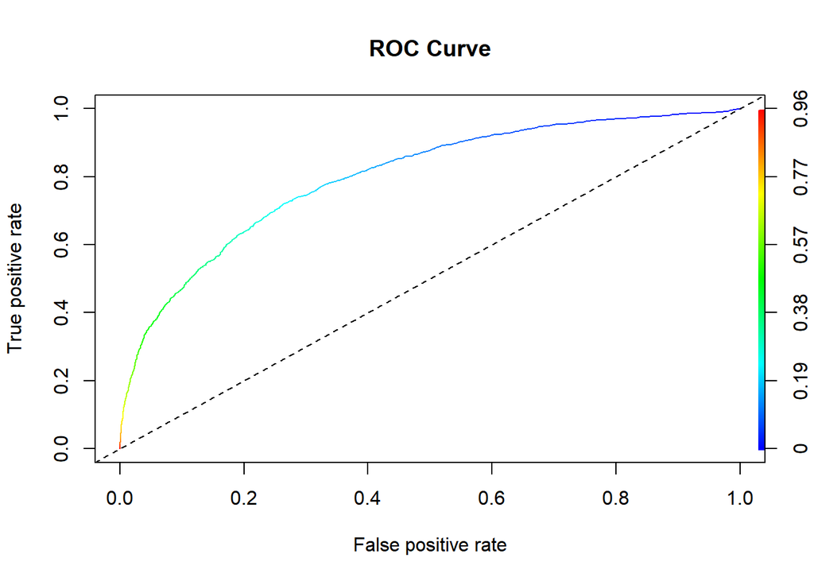

```r
pred <- prediction(test_data$pred_prob, test_data$loan_status)
perf <- performance(pred, "tpr", "fpr")
plot(perf, colorize = TRUE, main = "ROC Curve")
abline(a = 0, b = 1, lty = 2)
```

```r
# Calculate AUC
auc_log <- performance(pred, "auc")@y.values[[1]]
print(paste("AUC:", round(auc_log, 3)))
```

```
## [1] "AUC: 0.799"
```

```r
set.seed(123)

# Trying random forest to handle imbalance between paid and default
class_weights <- ifelse(train_data$loan_status == 1, 5, 1)  # 5x weight for defaults

rf_model_balanced <- randomForest(
  loan_status ~ person_age + person_income + loan_amnt + loan_intent +
                cb_person_default_on_file + income_loan_ratio,
  data = train_data,
  ntree = 200,
  classwt = c("0" = 1, "1" = 5),  # Explicit class weights
  importance = TRUE
)
```

```r
# Recreate income_loan_ratio in test_data
test_data$income_loan_ratio <- test_data$person_income / test_data$loan_amnt

# Predict probabilities
test_data$rf_prob <- predict(rf_model_balanced, newdata = test_data, type = "prob")[, 2]

# Convert to binary predictions (threshold = 0.5)
test_data$rf_pred <- ifelse(test_data$rf_prob > 0.5, 1, 0)
```

```r
conf_matrix_rf <- confusionMatrix(as.factor(test_data$rf_pred),
                                as.factor(test_data$loan_status))
print(conf_matrix_rf)
```

```
## Confusion Matrix and Statistics
##
##           Reference
## Prediction    0    1
##          0 5829  808
##          1  539  969
##
##                Accuracy : 0.8346
##                  95% CI : (0.8264, 0.8426)
##     No Information Rate : 0.7818
##     P-Value [Acc > NIR] : < 2.2e-16
##
##                   Kappa : 0.4872
##
##  Mcnemar's Test P-Value : 2.832e-13
##
##             Sensitivity : 0.9154
##             Specificity : 0.5453
##          Pos Pred Value : 0.8783
##          Neg Pred Value : 0.6426
##              Prevalence : 0.7818
##          Detection Rate : 0.7157
##    Detection Prevalence : 0.8149
##       Balanced Accuracy : 0.7303
##
##        'Positive' Class : 0
##
```

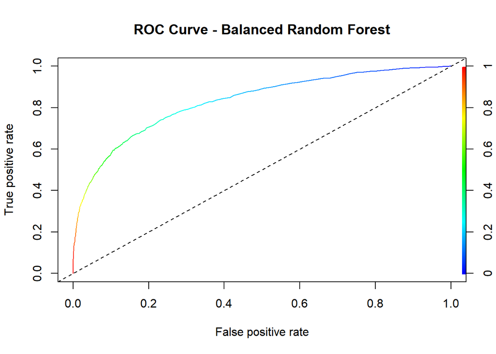

```r
pred_rf <- prediction(test_data$rf_prob, test_data$loan_status)
perf_rf <- performance(pred_rf, "tpr", "fpr")

plot(perf_rf, colorize=TRUE, main="ROC Curve - Balanced Random Forest")
abline(a=0, b=1, lty=2)
```

```r
# Calculate AUC
auc_rf <- performance(pred_rf, "auc")@y.values[[1]]
print(paste("AUC:", round(auc_rf, 3)))
```

```
## [1] "AUC: 0.831"
```

This project aimed to predict credit risk by analyzing loan applicant data to determine whether borrowers would default. Starting with a dataset of 32,581 loans, I performed exploratory data analysis to identify key trends: defaults were more common among renters, high-risk loan purposes (medical, debt consolidation), and applicants with higher loan amounts relative to income.

I built and compared two supervised learning models in R:

1. Logistic Regression: Provided interpretable coefficients but struggled with class imbalance, catching only 34% of defaults.
2. Balanced Random Forest: Improved default detection to 54.5% by weighting defaults more heavily, while maintaining 83.5% accuracy and a stronger AUC.

This project highlights how machine learning can uncover actionable insights in financial risk, providing a foundation for real-world credit scoring systems. By methodically cleaning data, engineering features, and iterating on models, I transformed raw data into a predictive tool with measurable business value.